# Assignment 3: Image Colourization [50 Pt]

### Part (iii) [1pt RESULTS]

Re-train a couple of new models using a different number of training epochs. You may train each new models in a new code cell by copying and modifying the code from the last notebook cell. Comment on how the results (output images, training loss) change as we increase or decrease the number of epochs.

```
Loading data...
File path: data/cifar-10-batches-py.tar.gz
Transforming data...
Beginning training ...
[epoch 000] train_loss=0.213724 (logged)
[epoch 005] train_loss=0.015597 (logged)
[epoch 010] train_loss=0.012552 (logged)
[epoch 015] train_loss=0.011023 (logged)
[epoch 020] train_loss=0.010018 (logged)
[epoch 025] train_loss=0.009337 (logged)
[epoch 030] train_loss=0.008851 (logged)
[epoch 035] train_loss=0.008470 (logged)
[epoch 040] train_loss=0.008144 (logged)
[epoch 045] train_loss=0.007845 (logged)
[epoch 050] train_loss=0.007567 (logged)
[epoch 055] train_loss=0.007337 (logged)
[epoch 060] train_loss=0.007137 (logged)
[epoch 065] train_loss=0.006950 (logged)
[epoch 070] train_loss=0.006776 (logged)
[epoch 075] train_loss=0.006617 (logged)
```

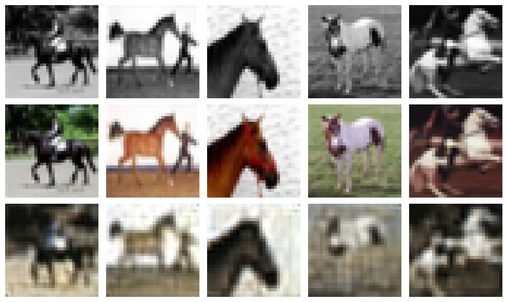

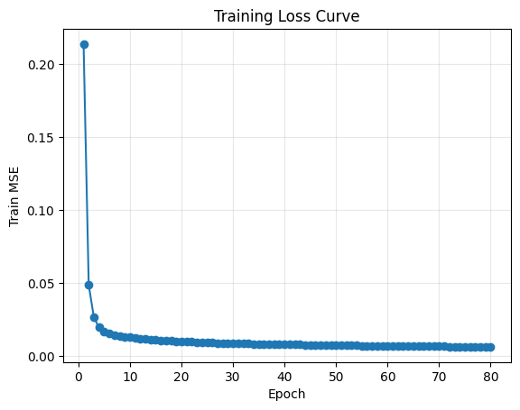

```
Training done. CSV logged. Loss curve displayed (not saved).
```

```python
# Model 1 - Epochs 80
args = AttrDict()
args_dict = {
    "gpu": True,
    "valid": False,
    "checkpoint": "",
    "colours": "./data/colours/colour_kmeans24_cat7.npy",
    "model": "RegressionCNN",
    "kernel": 3,
    "num_filters": 32,
    'learn_rate':0.001,
    "batch_size": 100,
    "epochs": 80,
    "seed": 0,
    "plot": True,
    "experiment_name": "colourization_cnn",
    "visualize": False,
    "downsize_input": False,
}

args.update(args_dict)
cnn = train(args)
```

```
Loading data...
File path: data/cifar-10-batches-py.tar.gz
Transforming data...
Beginning training ...
[epoch 000] train_loss=0.070227 (logged)
[epoch 005] train_loss=0.013050 (logged)
[epoch 010] train_loss=0.010916 (logged)
[epoch 015] train_loss=0.009843 (logged)
[epoch 020] train_loss=0.009076 (logged)
[epoch 025] train_loss=0.008583 (logged)
[epoch 030] train_loss=0.008223 (logged)
[epoch 035] train_loss=0.007932 (logged)
[epoch 040] train_loss=0.007658 (logged)
[epoch 045] train_loss=0.007399 (logged)
[epoch 050] train_loss=0.007166 (logged)
[epoch 055] train_loss=0.006965 (logged)
[epoch 060] train_loss=0.006798 (logged)
[epoch 065] train_loss=0.006643 (logged)
[epoch 070] train_loss=0.006499 (logged)
[epoch 075] train_loss=0.006358 (logged)
[epoch 080] train_loss=0.006224 (logged)
[epoch 085] train_loss=0.006109 (logged)
[epoch 090] train_loss=0.006015 (logged)
[epoch 095] train_loss=0.005927 (logged)
[epoch 100] train_loss=0.005839 (logged)
[epoch 105] train_loss=0.005760 (logged)
[epoch 110] train_loss=0.005693 (logged)
[epoch 115] train_loss=0.005627 (logged)
[epoch 120] train_loss=0.005567 (logged)
[epoch 125] train_loss=0.005502 (logged)
[epoch 130] train_loss=0.005449 (logged)
[epoch 135] train_loss=0.005437 (logged)
[epoch 140] train_loss=0.005356 (logged)
[epoch 145] train_loss=0.005304 (logged)
[epoch 150] train_loss=0.005271 (logged)
[epoch 155] train_loss=0.005312 (logged)
[epoch 160] train_loss=0.005283 (logged)
[epoch 165] train_loss=0.005170 (logged)
[epoch 170] train_loss=0.005119 (logged)
[epoch 175] train_loss=0.005224 (logged)
[epoch 180] train_loss=0.005162 (logged)
[epoch 185] train_loss=0.005111 (logged)
[epoch 190] train_loss=0.004986 (logged)
[epoch 195] train_loss=0.004942 (logged)
[epoch 200] train_loss=0.004994 (logged)
[epoch 205] train_loss=0.004984 (logged)
[epoch 210] train_loss=0.004927 (logged)
[epoch 215] train_loss=0.004876 (logged)
[epoch 220] train_loss=0.004862 (logged)
[epoch 225] train_loss=0.004939 (logged)
[epoch 230] train_loss=0.004782 (logged)
[epoch 235] train_loss=0.004730 (logged)
[epoch 240] train_loss=0.004697 (logged)
[epoch 245] train_loss=0.004689 (logged)
[epoch 250] train_loss=0.004697 (logged)
[epoch 255] train_loss=0.004727 (logged)
```

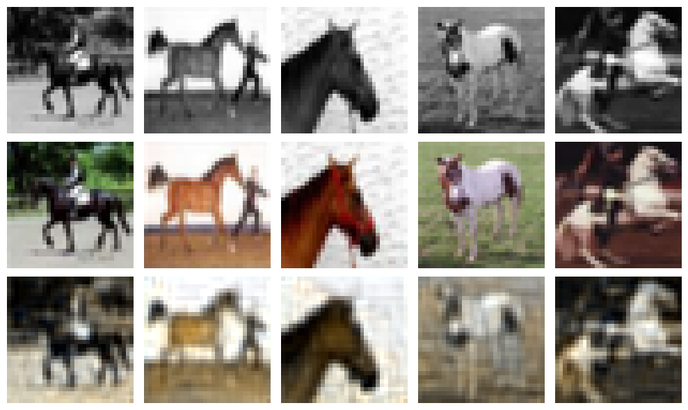

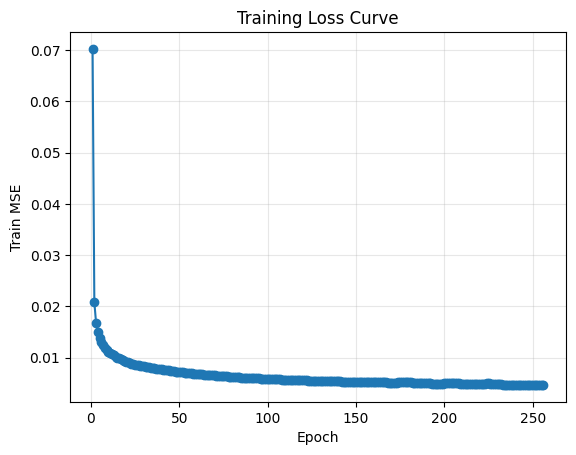

```
Training done. CSV logged. Loss curve displayed (not saved).
```

```python
# Model 2 - Epochs 256
args = AttrDict()
args_dict = {
    "gpu": True,
    "valid": False,
    "checkpoint": "",
    "colours": "./data/colours/colour_kmeans24_cat7.npy",
    "model": "RegressionCNN",
    "kernel": 3,
    "num_filters": 32,
    'learn_rate':0.001,
    "batch_size": 100,
    "epochs": 256,
    "seed": 0,
    "plot": True,
    "experiment_name": "colourization_cnn",
    "visualize": False,
    "downsize_input": False,
}

args.update(args_dict)
cnn = train(args)
```

```
Loading data...
File path: data/cifar-10-batches-py.tar.gz
Transforming data...
Beginning training ...
[epoch 000] train_loss=0.441736 (logged)
[epoch 005] train_loss=0.016955 (logged)
[epoch 010] train_loss=0.012462 (logged)
[epoch 015] train_loss=0.010950 (logged)
[epoch 020] train_loss=0.009968 (logged)
[epoch 025] train_loss=0.009304 (logged)
[epoch 030] train_loss=0.008827 (logged)
[epoch 035] train_loss=0.008454 (logged)
[epoch 040] train_loss=0.008143 (logged)
[epoch 045] train_loss=0.007868 (logged)
[epoch 050] train_loss=0.007628 (logged)
[epoch 055] train_loss=0.007310 (logged)
[epoch 060] train_loss=0.007071 (logged)
[epoch 065] train_loss=0.006866 (logged)
[epoch 070] train_loss=0.006695 (logged)
[epoch 075] train_loss=0.006546 (logged)
[epoch 080] train_loss=0.006414 (logged)
[epoch 085] train_loss=0.006293 (logged)
[epoch 090] train_loss=0.006186 (logged)
[epoch 095] train_loss=0.006091 (logged)
[epoch 100] train_loss=0.006002 (logged)
[epoch 105] train_loss=0.005919 (logged)
[epoch 110] train_loss=0.005850 (logged)
[epoch 115] train_loss=0.005793 (logged)
[epoch 120] train_loss=0.005798 (logged)
[epoch 125] train_loss=0.005830 (logged)
[epoch 130] train_loss=0.005700 (logged)
[epoch 135] train_loss=0.005652 (logged)
[epoch 140] train_loss=0.005593 (logged)
[epoch 145] train_loss=0.005533 (logged)
[epoch 150] train_loss=0.005490 (logged)
[epoch 155] train_loss=0.005453 (logged)
[epoch 160] train_loss=0.005414 (logged)
[epoch 165] train_loss=0.005369 (logged)
[epoch 170] train_loss=0.005327 (logged)
[epoch 175] train_loss=0.005295 (logged)
```

[output cut: 52 more lines]

```
[epoch 440] train_loss=0.004606 (logged)
[epoch 445] train_loss=0.004666 (logged)
[epoch 450] train_loss=0.004586 (logged)
[epoch 455] train_loss=0.004588 (logged)
[epoch 460] train_loss=0.004579 (logged)
[epoch 465] train_loss=0.004548 (logged)
[epoch 470] train_loss=0.004556 (logged)
[epoch 475] train_loss=0.004629 (logged)
[epoch 480] train_loss=0.004711 (logged)
[epoch 485] train_loss=0.004780 (logged)
[epoch 490] train_loss=0.004592 (logged)
[epoch 495] train_loss=0.004485 (logged)
[epoch 500] train_loss=0.004465 (logged)
[epoch 505] train_loss=0.004466 (logged)
[epoch 510] train_loss=0.004475 (logged)
```

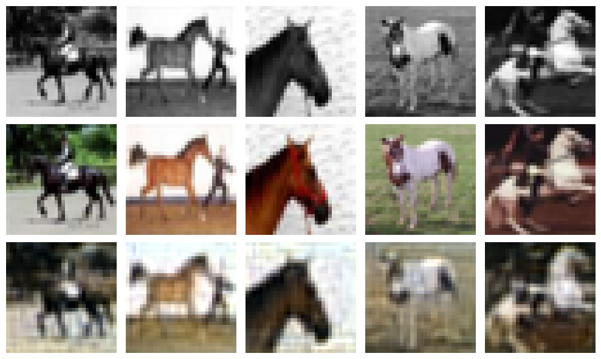

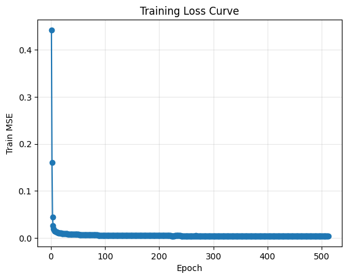

```
Training done. CSV logged. Loss curve displayed (not saved).
```

```python
# Model 3 - Epochs 512
args = AttrDict()
args_dict = {
    "gpu": True,
    "valid": False,
    "checkpoint": "",
    "colours": "./data/colours/colour_kmeans24_cat7.npy",
    "model": "RegressionCNN",
    "kernel": 3,
    "num_filters": 32,
    'learn_rate':0.001,
    "batch_size": 100,
    "epochs": 512,
    "seed": 0,
    "plot": True,
    "experiment_name": "colourization_cnn",
    "visualize": False,
    "downsize_input": False,
}

args.update(args_dict)
cnn = train(args)
```

```
Loading data...
File path: data/cifar-10-batches-py.tar.gz
Transforming data...
Beginning training ...
[epoch 000] train_loss=0.134524 (logged)
[epoch 005] train_loss=0.013852 (logged)
[epoch 010] train_loss=0.011013 (logged)
[epoch 015] train_loss=0.009831 (logged)
```

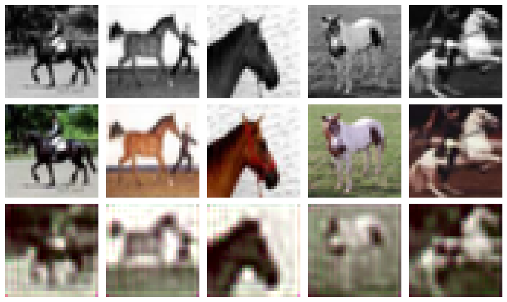

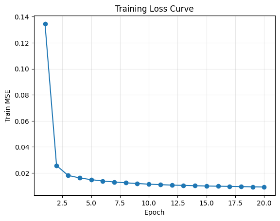

```
Training done. CSV logged. Loss curve displayed (not saved).
```

```python
# Model 4 - Epochs 20
args = AttrDict()
args_dict = {
    "gpu": True,
    "valid": False,
    "checkpoint": "",
    "colours": "./data/colours/colour_kmeans24_cat7.npy",
    "model": "RegressionCNN",
    "kernel": 3,
    "num_filters": 32,
    'learn_rate':0.001,
    "batch_size": 100,
    "epochs": 20,
    "seed": 0,
    "plot": True,
    "experiment_name": "colourization_cnn",
    "visualize": False,
    "downsize_input": False,
}

args.update(args_dict)
cnn = train(args)
```

```python
'''
When the epochs increases slightly (i.e. 51 -> 80), the generated color images show basic brown/green framework and basic edges, but still low saturation and color spills. Traninig loss decreases obviously.

When the epochs increases slightly (i.e. 80 -> 256), the generated color images show stronger brown/green distinguishment and more vibrant, but rare color like purple still gets averaged by MSE. Traninig loss decreases obviously.

When the epochs increases slightly (i.e. 256 -> 512), the generated color images show better details handling like color is closer to original image but not much improvement visually. Traninig loss drops a bit, almost remain the same.

When the epochs increases slightly (i.e. 51 -> 20), the generated color images show very blur and color spills situation, which is more like underfitting. Traninig increases a lot.

To sum up, the training loss decrease slowlier as larger epochs are trained, the generated images colorization is more smooth as larger epochs are trained but limits in improvement visually.

'''
```

### Part (iv) [2pt MODEL]

Modify the autoencoder archeticture to use transposed convolution layers for the decoder portion. Ensure that the appropriate parameters are modified (e.g. input and output channels, padding) to accommodate this change. Train your model and present your best results. Hint1: Please check Pre3A_Autoencoder.ipynb for examples on how to use transposed convolution layers. Hint2: the output dimensions of upconv1 when using ConvTranspose2d for example should match the output of upconv1 when using Conv2d.

```python
class RegressionCNN(nn.Module):
    def __init__(self, kernel, num_filters):
        # first call parent's initialization function
        super().__init__()
        padding = kernel // 2

        self.downconv1 = nn.Sequential(
            nn.Conv2d(1, num_filters, kernel_size=kernel, padding=padding),                         # 32 -> 32
            nn.BatchNorm2d(num_filters),
            nn.ReLU(),
            nn.MaxPool2d(2),)                                                                       # 32 -> 16
        self.downconv2 = nn.Sequential(
            nn.Conv2d(num_filters, num_filters*2, kernel_size=kernel, padding=padding),             # 16 -> 16
            nn.BatchNorm2d(num_filters*2),
            nn.ReLU(),
            nn.MaxPool2d(2),)                                                                       # 16 -> 8

        self.rfconv = nn.Sequential(
            nn.Conv2d(num_filters*2, num_filters*2, kernel_size=kernel, padding=padding),
            nn.BatchNorm2d(num_filters*2),
            nn.ReLU())

# ======== COMPLETED ==========
        self.upconv1 = nn.Sequential(
            nn.ConvTranspose2d(num_filters*2, num_filters, kernel_size=kernel, padding=padding, stride=2, output_padding=1),    # 8 -> 16
            nn.BatchNorm2d(num_filters),
            nn.ReLU()
        )

        self.upconv2 = nn.Sequential(
            nn.ConvTranspose2d(num_filters, 3, kernel_size=kernel, padding=padding, stride=2, output_padding=1),                # 16 -> 32
            nn.BatchNorm2d(3),
            nn.ReLU()
        )
# =============================
        self.finalconv = nn.Conv2d(3, 3, kernel_size=kernel, padding=padding)

    def forward(self, x):
        out = self.downconv1(x)
        out = self.downconv2(out)
        out = self.rfconv(out)
        out = self.upconv1(out)
        out = self.upconv2(out)
        out = self.finalconv(out)
        return out
```

```
Loading data...
File path: data/cifar-10-batches-py.tar.gz
Transforming data...
Beginning training ...
[epoch 000] train_loss=0.155797 (logged)
[epoch 005] train_loss=0.011528 (logged)
[epoch 010] train_loss=0.008647 (logged)
[epoch 015] train_loss=0.007454 (logged)
[epoch 020] train_loss=0.006776 (logged)
[epoch 025] train_loss=0.006329 (logged)
[epoch 030] train_loss=0.005982 (logged)
[epoch 035] train_loss=0.005719 (logged)
[epoch 040] train_loss=0.005516 (logged)
[epoch 045] train_loss=0.005358 (logged)
[epoch 050] train_loss=0.005229 (logged)
```

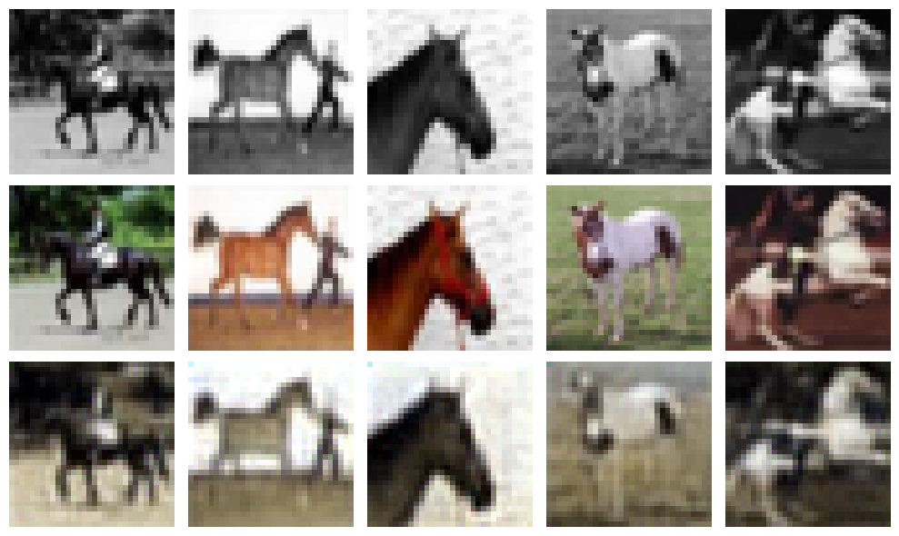

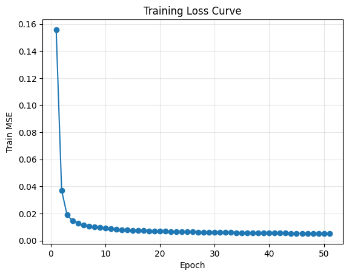

```
Training done. CSV logged. Loss curve displayed (not saved).
```

```python
#Main training loop for CNN
args = AttrDict()
args_dict = {
    "gpu": True,
    "valid": False,
    "checkpoint": "",
    "colours": "./data/colours/colour_kmeans24_cat7.npy",
    "model": "RegressionCNN",
    "kernel": 3,
    "num_filters": 32,
    'learn_rate':0.001,
    "batch_size": 100,
    "epochs": 51,
    "seed": 0,
    "plot": True,
    "experiment_name": "colourization_cnn",
    "visualize": False,
    "downsize_input": False,
}

args.update(args_dict)
cnn = train(args)
```

```
Loading data...
File path: data/cifar-10-batches-py.tar.gz
Transforming data...
Beginning training ...
[epoch 000] train_loss=0.164865 (logged)
[epoch 005] train_loss=0.014435 (logged)
[epoch 010] train_loss=0.010869 (logged)
[epoch 015] train_loss=0.009328 (logged)
[epoch 020] train_loss=0.008378 (logged)
[epoch 025] train_loss=0.007641 (logged)
[epoch 030] train_loss=0.007056 (logged)
[epoch 035] train_loss=0.006618 (logged)
[epoch 040] train_loss=0.006280 (logged)
[epoch 045] train_loss=0.006012 (logged)
[epoch 050] train_loss=0.005787 (logged)
[epoch 055] train_loss=0.005602 (logged)
[epoch 060] train_loss=0.005450 (logged)
[epoch 065] train_loss=0.005318 (logged)
[epoch 070] train_loss=0.005205 (logged)
[epoch 075] train_loss=0.005104 (logged)
```

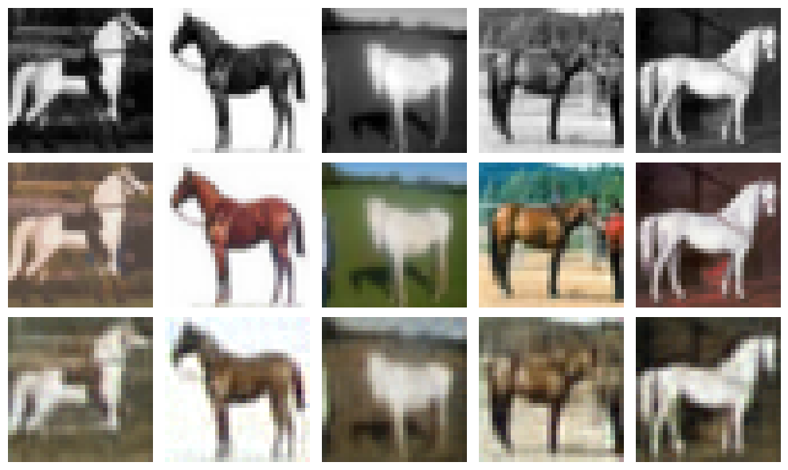

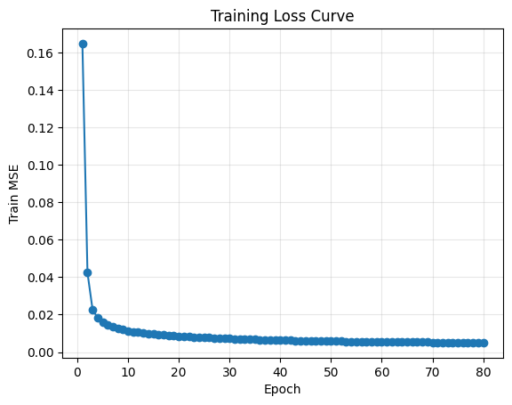

```
Training done. CSV logged. Loss curve displayed (not saved).
```

```python
#Model 1 - lr=0.002, batch size=256, epochs=80
args = AttrDict()
args_dict = {
    "gpu": True,
    "valid": False,
    "checkpoint": "",
    "colours": "./data/colours/colour_kmeans24_cat7.npy",
    "model": "RegressionCNN",
    "kernel": 3,
    "num_filters": 32,
    'learn_rate':0.002,
    "batch_size": 256,
    "epochs": 80,
    "seed": 0,
    "plot": True,
    "experiment_name": "colourization_cnn",
    "visualize": False,
    "downsize_input": False,
}

args.update(args_dict)
cnn = train(args)
```